# DSCI 304 - Final Project

Taylor Shui

2022-11-18

## Part I: Introduction:

As a big baseball fan and a native Houstonian, I chose to base my final project for DSCI 304 - Data Visualization on baseball and Houston’s resident MLB team, the Astros, deciding that it was a particularly fitting - and relevant - topic after Houston captured its 2nd World Series title a few weeks ago.

Houston’s postseason run was one for the ages; in addition to successfully capturing another World Series trophy, the Astros managed to make history. Throughout the course of the 2022 regular season, Houston’s pitching staff was the talk of the town, with season highlights including a no-hitter at Yankee Stadium, two immaculate innings pitched in the same game against the Texas Rangers, and emerging ace Framber Valdez setting a new MLB single-season quality start record, with 25 straight quality starts in a row. This elite level of pitching carried over to the postseason, as four Astros pitchers (starter Cristian Javier and relievers Bryan Abreu, Rafael Montero, and Ryan Pressly) led Houston to a much-needed World Series Game 4 in a decisive fashion by throwing a combined no-hitter. All in all, Houston’s bullpen posted a 0.83 ERA in the 2022 postseason, the lowest ever by any team in MLB postseason history, again emphasizing the dominance of the Astros’ pitching corpus.

Houston’s elite pitching was one of the strongest - if not the strongest - factors in their postseason run, and as such, I decided to take a look at their 2022 team’s overall profile and then turn my focus on their pitching corpus.

## Part II: Team Overview

First, I looked at MLB team payrolls for the 2022 season, investigating whether there exists a relationship between the total number of wins a team had at the conclusion of the 162-game regular season and their total 2022 team payroll.

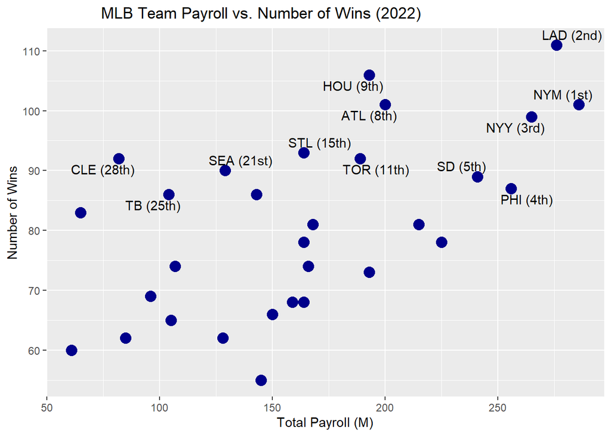

As we can see from the scatter plot above, there seems to be a positive, almost linear relationship between a team’s payroll and the number of wins it accumulates during the regular season. Logically, this observation does make sense: a team that spends more is able to secure more high-end talent and more easily bolster and maintain a competitive roster. We can see that this is supported by the results of the 2022 regular season. The Los Angeles Dodgers, the team with the 2nd highest payroll in 2022, led MLB with 111 regular season wins, while the top 3 teams in payroll (the Mets, the Dodgers, and the Yankees) all had close to or above 100 wins. Thus, while Houston is no slouch when it comes to payroll spending (9th in MLB), that it is not one of the top spenders makes its successful regular season and postseason even more respectable.

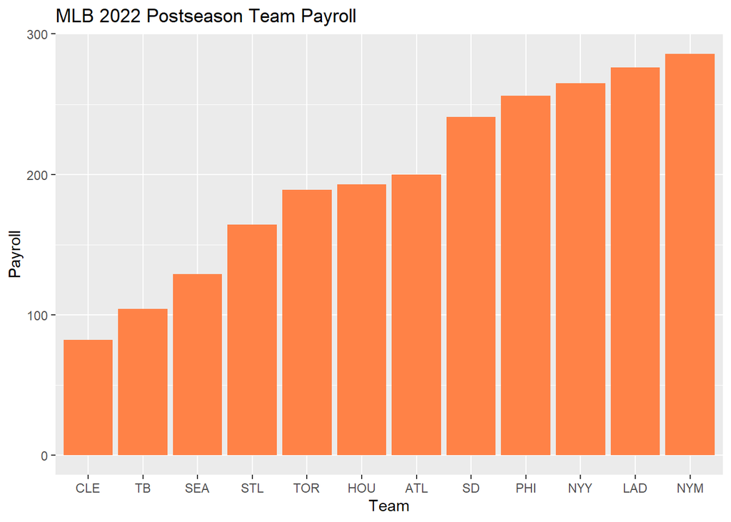

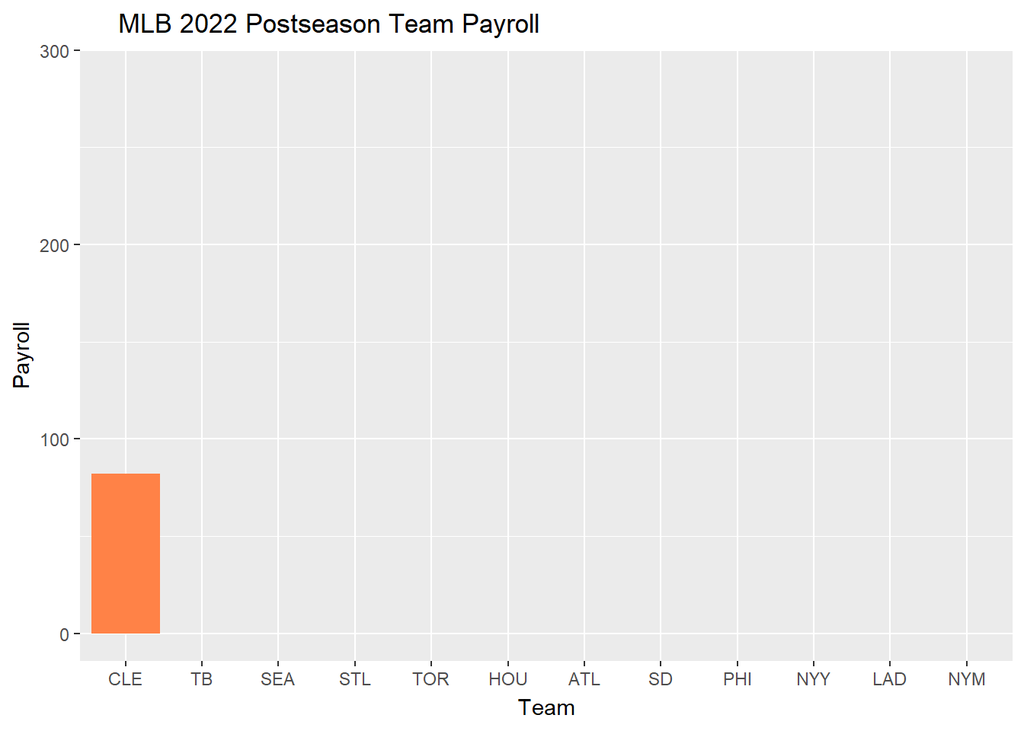

Next, I decided to continue exploring teams’ payrolls but with a focus on postseason teams only (that is, the 12 teams that qualified for MLB’s 2022 postseason under the expanded playoffs). We can see from the graph that Houston is roughly in the middle of the pack when it comes to payroll among the 12 postseason contenders; while the Astros aren’t as careful with their payroll as teams such as Cleveland and Tampa Bay, they also aren’t free-wheeling spenders like the Dodgers and the two New York teams.

Note that I included a static and animated version of the same visual, allowing for easier comparison between bars while preserving the novelty of an animated graph.

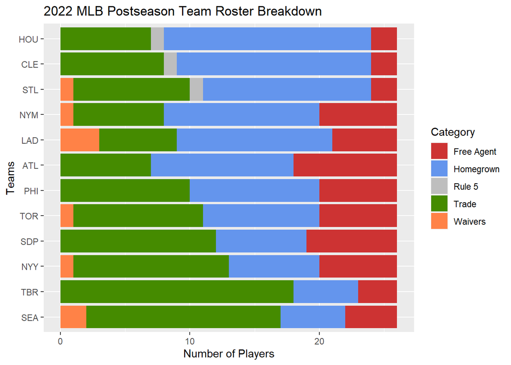

Following my exploration of payroll (and its relationship with team success on the field), I wanted to turn my focus in a different direction and take a look at teams’ roster construction and how they acquired each player on their rosters. More specifically, I broke down each of the 12 postseason contenders’ rosters by the number of free agents, homegrown talent, Rule 5 Draft pick-ups, trade-acquired players, and players claimed off of waivers.

Again, focusing on Houston, we can see that Houston has the highest number of homegrown players (blue) out of the 12 teams, a credit to its player development and scouting teams. Tampa Bay, a team known for its small payrolls and shrewd use of analytics, has the highest number of players acquired from trades. And Houston, Cleveland, and St. Louis are all tied for the fewest number of players signed as free agents on their postseason rosters.

## Part III: Focusing on Pitching

After a brief overview of 2022 teams, I’ll turn my focus to Houston’s pitching staff (and how it compares to other teams in both the 2022 regular season and the 2022 postseason). I first use a collapsible tree to visualize Houston’s pitching corpus (Note that the collapsible tree is interactive and can be expanded to show the progression of branches).

[interactive chart not shown]

The collapsible tree essentially illustrates a breakdown of Houston’s pitching staff, first grouping the entire pitching staff into their overall roles as part of the team (as a starting pitcher or a relief pitcher) and then whether they are considered RHP (right-hand pitchers) or LHP (left-hand pitchers). Note that I only included pitchers who made at least one appearance in the postseason or were part of all three postseason rosters (ALDS, ALCS, WS). Notably, left-handed pitcher Will Smith, a 2022 trade deadline acquisition, was excluded from the visual due to his exclusion from the first two postseason rosters and his lack of appearances in the 2022 postseason.

As we can see from the visual, the lone southpaw (lefty) on the Astros’ postseason was starter Framber Valdez. This was particularly interesting to me because a team usually likes to have at least 1-2 left handed relievers (not including starters) on its roster for the postseason to better match up against left-handed opposing batters (or right-handed batters who don’t fare as well as they should against LHPs). The trade that brought Will Smith to the Astros was made because of the lack of a prominent left-handed relief pitcher, and that he did not pitch a single inning in the postseason is a testament to the strength and depth of Houston’s pitching corpus as a whole. Essentially, whether an opposing batter was a left-handed batter or a right-handed batter didn’t matter - Houston pitchers stayed more than effective.

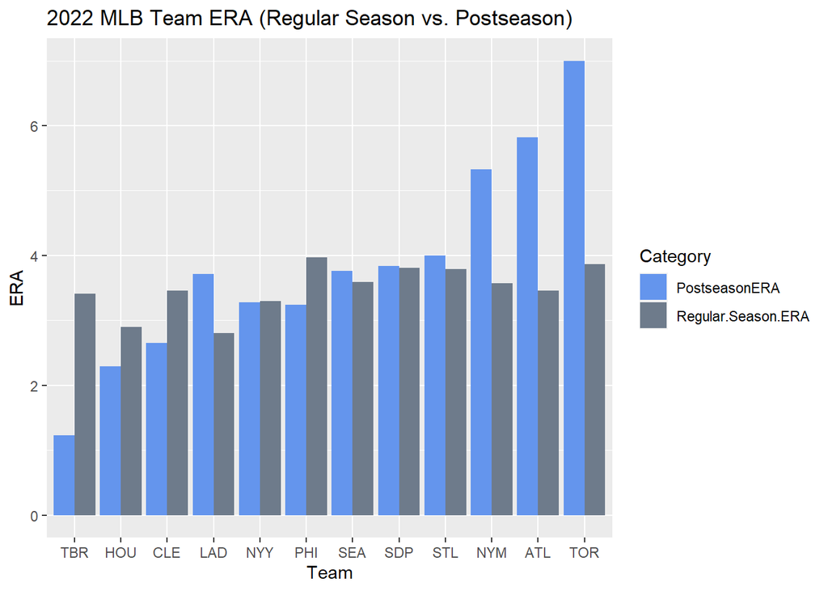

Next, I visualized each of the postseason teams’ ERA, comparing their 2022 regular season team ERA and their 2022 postseason team ERA to compare an individual team’s regular season and postseason pitching performance and also compare and contrast pitching performances between different teams.

From the bar chart, we can see that Los Angeles led MLB in team ERA in the regular season, followed closely by Houston. However, in the postseason, Tampa Bay had the lowest team ERA, followed (again) by Houston. We can also see that the Yankees, among a few teams, remained remarkably consistent in that their pitching staff’s ERA in the regular season was essentially the same as its ERA in the postseason. Unfortunately, the Mets, the Braves, and the Blue Jays, teams that had serviceable (if not improveable) team ERAs in the regular season, saw their ERA numbers increase significantly during the postseason, an indicator of their failure to advance past their respective first rounds in the postseason. Lastly, it is impressive that Houston’s ERA mark decreased from an already respectable number in the regular season to an even lower number in the postseason, again emphasizing the strength of its pitching staff.

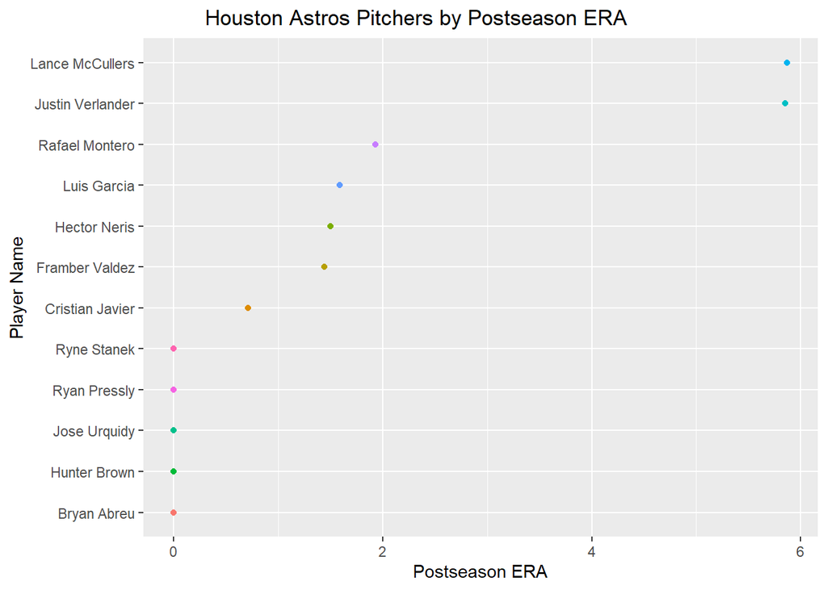

To conclude my final project, I wanted to explore Houston’s pitching staff one more time, focusing on its individual relievers. Looking at the dot plot, which showcases each player that pitched in the postseason and his respective ERA, we can see that there were multiple (5!!) pitchers with an ERA of zero, including closer Ryan Pressly and rookie Hunter Brown, who was a late September call-up and impressed enough to make the postseason roster. Ironically, two of Houston’s most decorated pitchers, then 2-time (3-time after the 2022 season) Cy-Young winner Justin Verlander and last year’s ace for the Astros Lance McCullers Jr. had the highest ERAs in the postseason (although Verlander tends to be notorious for doing poorly in the postseason compared to the regular season and McCullers had been shaky in more than a few prior postseason performances). However, when looking at the bigger picture, all but two pitchers (Verlander and McCullers, who were both starting pitchers) had ERAs under 2.00, and the availability of so many quality arms no doubt led Houston to its 2nd championship.